# Smad2 vs Smad3 Differential Binding Analysis after TGF-beta Treatment

### 2.2.4 Creating tibbles from peak annotation data

```r
df_ls2_vs_ns3_smad2enriched <- AnnotationDbi::as.data.frame(ap_ls2_vs_ns3_smad2enriched) %>% as_tibble() %>%
  dplyr::select(seqnames, start, end, width, annotation, GENENAME, log10_LR, SYMBOL, geneId, ENSEMBL, everything())

df_ls2_vs_ns3_smad3enriched <- AnnotationDbi::as.data.frame(ap_ls2_vs_ns3_smad3enriched) %>% as_tibble() %>%
  dplyr::select(seqnames, start, end, width, annotation, GENENAME, log10_LR, SYMBOL, geneId, ENSEMBL, everything())

df_ls2_vs_ns3_bothenriched <- AnnotationDbi::as.data.frame(ap_ls2_vs_ns3_bothenriched) %>% as_tibble() %>%
  dplyr::select(seqnames, start, end, width, annotation, GENENAME, log10_LR, SYMBOL, geneId, ENSEMBL, everything())
```

### 2.2.5 Extracting unique list of genes containing promoter-proximal peaks

```r
prom_genes_ls2_vs_ns3_smad2enriched <- df_ls2_vs_ns3_smad2enriched %>% filter(str_detect(string = annotation, pattern = "Promoter")) %>%
  dplyr::select(GENENAME, geneId) %>%
  distinct(geneId, .keep_all = TRUE) %>%
  tidyr::drop_na()

prom_genes_ls2_vs_ns3_smad3enriched <-  df_ls2_vs_ns3_smad3enriched %>% filter(str_detect(string = annotation, pattern = "Promoter")) %>%
  dplyr::select(GENENAME, geneId) %>%
  distinct(geneId, .keep_all = TRUE) %>%
  tidyr::drop_na()


prom_genes_ls2_vs_ns3_bothenriched <-  df_ls2_vs_ns3_bothenriched %>% filter(str_detect(string = annotation, pattern = "Promoter")) %>%
  dplyr::select(GENENAME, geneId) %>%
  distinct(geneId, .keep_all = TRUE) %>%
  tidyr::drop_na()
```

#### 2.2.5.1 Genes containing promoter-proximal differentially-enriched Smad2 peaks

```r
prom_genes_ls2_vs_ns3_smad2enriched
```

| GENENAME | geneId |
| --- | --- |
| long intergenic non-protein coding RNA 1160 | 100129269 |
| mucin 1, cell surface associated | 4582 |
| regulator of G protein signaling like 1 | 353299 |
| SET and MYND domain containing 2 | 56950 |
| zinc finger MYND-type containing 11 | 10771 |
| BicC family RNA binding protein 1 | 80114 |
| calcium/calmodulin dependent protein kinase II gamma | 818 |
| zinc finger MIZ-type containing 1 | 57178 |
| 5-hydroxytryptamine receptor 7 | 3363 |
| golgin A7 family member B | 401647 |

[output cut: 40 more lines]

```r
NA
```

#### 2.2.5.2 Genes containing promoter-proximal differentially-enriched Smad3 peaks

```r
prom_genes_ls2_vs_ns3_smad3enriched
```

| GENENAME | geneId |
| --- | --- |
| family with sequence similarity 138 member A | 645520 |
| uncharacterized LOC729737 | 729737 |
| microRNA 6859-1 | 102466751 |
| uncharacterized LOC100132287 | 100132287 |
| tubulin tyrosine ligase like 10 | 254173 |
| chromodomain helicase DNA binding protein 5 | 26038 |
| hes family bHLH transcription factor 3 | 390992 |
| pleckstrin homology and RhoGEF domain containing G5 | 57449 |
| kinesin family member 1B | 23095 |
| forkhead associated phosphopeptide binding domain 1 | 114827 |

[output cut: 990 more lines]

#### 2.2.5.3 Genes with promoter-proximal peaks which are not significantly differentially-enriched for either Smad2 or Smad3 binding

```r
prom_genes_ls2_vs_ns3_bothenriched
```

| GENENAME | geneId |
| --- | --- |
| CROCC pseudogene 2 | 84809 |
| tectorin alpha | 7007 |
| BRF1 RNA polymerase III transcription initiation factor subunit | 2972 |
| DEAD/H-box helicase 11 like 9 | 100288486 |
| RNA, U2 small nuclear 1 | 6066 |
| microRNA 8078 | 102466878 |
| uncharacterized LOC100134317 | 100134317 |
| uncharacterized LOC284412 | 284412 |
| solute carrier family 17 member 9 | 63910 |
| long intergenic non-protein coding RNA 1667 | 441058 |

[output cut: 18 more lines]

```r
NA
```

### 2.2.6 Performing set operations on LAP-Smad2 vs native-Smad3 gene lists

#### 2.2.6.1 Genes common to both the Smad2-differentially enriched peak set and the Smad3-differentially enriched peak set

```r
intersect(prom_genes_ls2_vs_ns3_smad2enriched$GENENAME, prom_genes_ls2_vs_ns3_smad3enriched$GENENAME) %>% # finding common peaks between LAP-Smad2 and LAP-Smad3
  tibble::enframe(name = "No.", value = "Promoter-proximal peak annotations") %>%
  tidyr::drop_na()
```

| No. | Promoter-proximal peak annotations |
| --- | --- |
| 1 | zinc finger MIZ-type containing 1 |
| 2 | microRNA 6724-1 |
| 3 | microRNA 3648-1 |
| 4 | RNA, 5.8S ribosomal N4 |
| 5 | forkhead box P4 |
| 6 | thromboxane A synthase 1 |

#### 2.2.6.2 Genes common to both the Smad2-differentially enriched peak set and the non-differentially expressed peak set

```r
intersect(prom_genes_ls2_vs_ns3_smad2enriched$GENENAME, prom_genes_ls2_vs_ns3_bothenriched$GENENAME) %>% # finding common peaks between LAP-Smad2 and LAP-Smad3
  tibble::enframe(name = "No.", value = "Promoter-proximal peak annotations") %>%
  tidyr::drop_na()
```

| No. | Promoter-proximal peak annotations |
| --- | --- |
| 1 | uncharacterized LOC100134317 |
| 2 | uncharacterized LOC284412 |
| 3 | coiled-coil domain containing 183 |

#### 2.2.6.3 Genes common to both the Smad3-differentially enriched peak set and the non-differentially expressed peak set

```r
intersect(prom_genes_ls2_vs_ns3_smad3enriched$GENENAME, prom_genes_ls2_vs_ns3_bothenriched$GENENAME) %>% # finding common peaks between LAP-Smad2 and LAP-Smad3
  tibble::enframe(name = "No.", value = "Promoter-proximal peak annotations") %>%
  tidyr::drop_na()
```

| No. | Promoter-proximal peak annotations |
| --- | --- |
| 1 | CROCC pseudogene 2 |
| 2 | DEAD/H-box helicase 11 like 9 |
| 3 | RNA, U2 small nuclear 1 |
| 4 | long intergenic non-protein coding RNA 1667 |
| 5 | C1q and TNF related 3 |
| 6 | putative POM121-like protein 1-like pseudogene |
| 7 | REXO1 like 2, pseudogene |
| 8 | DEAD/H-box helicase 11 like 5 |
| 9 | family with sequence similarity 27 member C |

```r
NA
```

#### 2.2.6.4 Collecting a list of “ambiguous” genes

```r
dplyr::union(intersect(prom_genes_ls2_vs_ns3_smad2enriched$GENENAME, prom_genes_ls2_vs_ns3_bothenriched$GENENAME),
      intersect(prom_genes_ls2_vs_ns3_smad3enriched$GENENAME,prom_genes_ls2_vs_ns3_bothenriched$GENENAME)) %>%
  dplyr::union(., intersect(prom_genes_ls2_vs_ns3_smad2enriched$GENENAME, prom_genes_ls2_vs_ns3_smad3enriched$GENENAME)) %>%
  tibble::enframe(name = "No.", value = "'Ambiguous' genes") %>%
  tidyr::drop_na()
```

| No. | 'Ambiguous' genes |
| --- | --- |
| 1 | uncharacterized LOC100134317 |
| 2 | uncharacterized LOC284412 |
| 3 | coiled-coil domain containing 183 |
| 4 | CROCC pseudogene 2 |
| 5 | DEAD/H-box helicase 11 like 9 |
| 6 | RNA, U2 small nuclear 1 |
| 7 | long intergenic non-protein coding RNA 1667 |
| 8 | C1q and TNF related 3 |
| 9 | putative POM121-like protein 1-like pseudogene |
| 10 | REXO1 like 2, pseudogene |

[output cut: 8 more lines]

```r
NA
```

```r
### Assigning 'ambiguous' genes to a variable

ambi_ls2_vs_ns3 <- dplyr::union(intersect(prom_genes_ls2_vs_ns3_smad2enriched$geneId, prom_genes_ls2_vs_ns3_bothenriched$geneId), intersect(prom_genes_ls2_vs_ns3_smad3enriched$geneId, prom_genes_ls2_vs_ns3_bothenriched$geneId)) %>%
  dplyr::union(., intersect(prom_genes_ls2_vs_ns3_smad2enriched$geneId, prom_genes_ls2_vs_ns3_smad3enriched$geneId))
```

### 2.2.7 GO term enrichment analysis

#### 2.2.7.1 GO terms enriched in Smad2-exclusive differentially enriched peaks

```r
prom_genes_ls2_vs_ns3_smad2enriched %>% filter(!geneId %in% ambi_ls2_vs_ns3)
```

| GENENAME | geneId |
| --- | --- |
| long intergenic non-protein coding RNA 1160 | 100129269 |
| mucin 1, cell surface associated | 4582 |
| regulator of G protein signaling like 1 | 353299 |
| SET and MYND domain containing 2 | 56950 |
| zinc finger MYND-type containing 11 | 10771 |
| BicC family RNA binding protein 1 | 80114 |
| calcium/calmodulin dependent protein kinase II gamma | 818 |
| 5-hydroxytryptamine receptor 7 | 3363 |
| golgin A7 family member B | 401647 |
| pleckstrin and Sec7 domain containing | 5662 |

[output cut: 31 more lines]

```r
NA
```

```r
### performing GO term analysis for this list of genes

ego_prom_genes_ls2_vs_ns3_smad2enriched <- enrichGO(gene = (prom_genes_ls2_vs_ns3_smad2enriched %>% filter(!geneId %in% ambi_ls2_vs_ns3) %>% dplyr::select(geneId) %>% unlist(use.names = FALSE)), org.Hs.eg.db, ont = "BP", pAdjustMethod = "BH", readable = TRUE)
```

No GO Terms were found to be differentially enriched in this list of genes.

```r
ego_prom_genes_ls2_vs_ns3_smad2enriched@result %>%
  as_tibble() %>%
  arrange(p.adjust, desc(Count) , desc(GeneRatio))  %>%
  filter(p.adjust < 0.05) %>%
  dplyr::select(Description, p.adjust, GeneRatio, BgRatio, geneID)
```

| Description | p.adjust | GeneRatio | BgRatio | geneID |
| --- | --- | --- | --- | --- |

```r
NA
```

#### 2.2.7.2 GO terms enriched in Smad3-exclusive differentially enriched peaks

| GENENAME | geneId |
| --- | --- |
| family with sequence similarity 138 member A | 645520 |
| uncharacterized LOC729737 | 729737 |
| microRNA 6859-1 | 102466751 |
| uncharacterized LOC100132287 | 100132287 |
| tubulin tyrosine ligase like 10 | 254173 |
| chromodomain helicase DNA binding protein 5 | 26038 |
| hes family bHLH transcription factor 3 | 390992 |
| pleckstrin homology and RhoGEF domain containing G5 | 57449 |
| kinesin family member 1B | 23095 |
| forkhead associated phosphopeptide binding domain 1 | 114827 |

[output cut: 990 more lines]

Performing the GO-Term analysis.

```r
ego_prom_genes_ls2_vs_ns3_smad3enriched <- enrichGO(gene = (prom_genes_ls2_vs_ns3_smad3enriched %>% filter(!geneId %in% ambi_ls2_vs_ns3) %>% dplyr::select(geneId) %>% unlist(use.names = FALSE)), org.Hs.eg.db, ont = "BP", pAdjustMethod = "BH", readable = TRUE)
```

```r
ego_prom_genes_ls2_vs_ns3_smad3enriched@result %>%
  as_tibble() %>%
  arrange(p.adjust, desc(GeneRatio), desc(Count))  %>%
  filter(p.adjust < 0.05) %>%
  dplyr::select(Description, p.adjust, GeneRatio, BgRatio, geneID)
```

| Description | p.adjust | GeneRatio | BgRatio | geneID |
| --- | --- | --- | --- | --- |
| positive regulation of GTPase activity | 0.001383027 | 45/928 | 405/18670 | DOCK7/VAV3/XCL1/SIPA1L2/GDI2/ITGB1/ARHGAP22/ADRB1/ARAP1/ARRB…… |
| actin filament bundle assembly | 0.001383027 | 24/928 | 153/18670 | RHOC/FMN2/PPFIA1/ARAP1/ARRB1/RDX/APOA1/PAWR/HSP90B1/PXN/EVL/TPM1/BAIAP2/ACTN4/CLASP1/MYO1B/SRC/CLASP2/MIR138-1/FAM107A/ITGB5/LIMCH1/NEDD9/TSC1 |
| actin filament bundle organization | 0.001491896 | 24/928 | 157/18670 | RHOC/FMN2/PPFIA1/ARAP1/ARRB1/RDX/APOA1/PAWR/HSP90B1/PXN/EVL/TPM1/BAIAP2/ACTN4/CLASP1/MYO1B/SRC/CLASP2/MIR138-1/FAM107A/ITGB5/LIMCH1/NEDD9/TSC1 |
| regulation of adherens junction organization | 0.005339767 | 14/928 | 67/18670 | RDX/CORO1C/FMN1/THBS1/MAP4K4/LIMS1/CLASP1/SRC/IQSEC1/CLASP2/FAM107A/LIMCH1/VEGFA/TSC1 |
| cell-substrate adhesion | 0.007052542 | 38/928 | 354/18670 | ADAM15/ITGB1/WASHC2C/PARVA/PPFIA1/APOA1/JAM3/CORO1C/PXN/FERM…… |
| regulation of cell morphogenesis | 0.007791499 | 47/928 | 484/18670 | EPB41/RHOC/DNM3/WASHC2C/PARVA/ARAP1/RDX/APOA1/CORO1C/NFATC4/…… |
| regulation of GTPase activity | 0.008436946 | 46/928 | 479/18670 | DOCK7/VAV3/XCL1/SIPA1L2/GDI2/ITGB1/ARHGAP22/ADRB1/ARAP1/ARRB…… |
| epithelial cell migration | 0.008436946 | 37/928 | 351/18670 | PLEKHG5/MIR135B/ITGB1/APOA1/ETS1/STRAP/HDAC7/CORO1C/PXN/LTB4…… |
| epithelium migration | 0.008436946 | 37/928 | 354/18670 | PLEKHG5/MIR135B/ITGB1/APOA1/ETS1/STRAP/HDAC7/CORO1C/PXN/LTB4…… |
| positive regulation of epithelial cell migration | 0.008436946 | 23/928 | 171/18670 | MIR135B/ETS1/HDAC7/THBS1/RAB11A/PDPK1/MAP3K3/ATOH8/MAP4K4/CLASP1/MIR10B/SRC/PLCG1/IQSEC1/CLASP2/TDGF1/ANXA3/PDCD6/FGF1/SPARC/VEGFA/SMOC2/MIR29A |

[output cut: 23 more lines]

Similar to the LAP-Smad2 versus LAP-Smad3 comparison, GO terms related to regulation of GTPase activity were once again present among the most enriched. However, terms related to cell morphogenesis, migration, cellular adhesion and cytoskeletal organisation and junction regulation also featured in the list of most-enriched GO terms. These GO terms were significantly different from those found for the LAP-Smad2 versus LAP-Smad3 comparison.

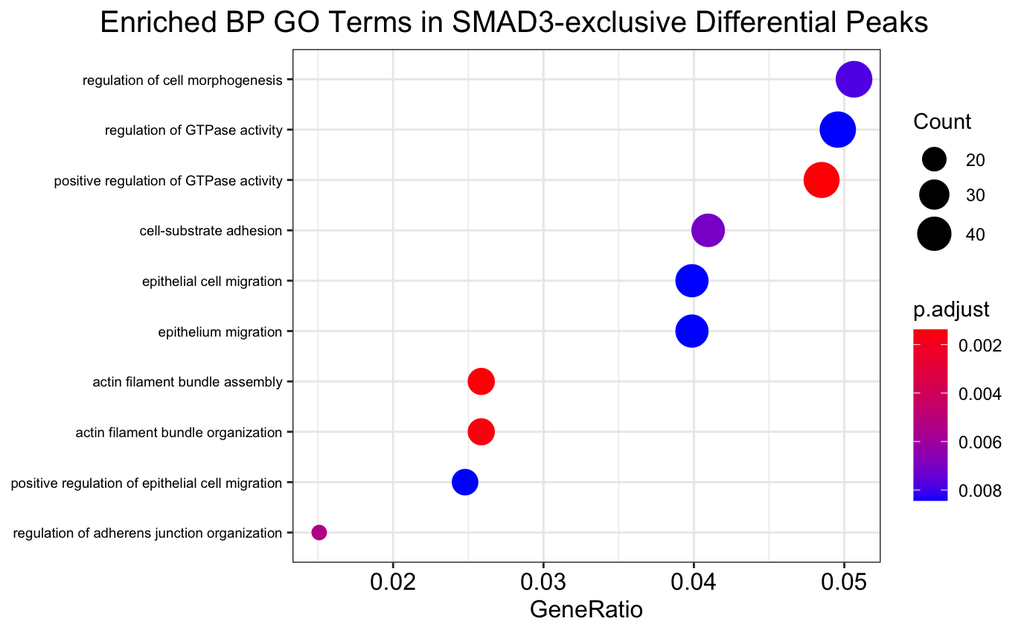

```r
dotplot(ego_prom_genes_ls2_vs_ns3_smad3enriched) +
  ggtitle(label = "Enriched BP GO Terms in SMAD3-exclusive Differential Peaks") +
  theme(plot.title = element_text(hjust = 0.8, size = 15), axis.text.y = element_text(size = 7))
```